# Homework Assignment 1: Solutions

# Question 3: Turnout Model with Penalized Logistic Regression

In the previous question, we used our knowledge of the political science literature, and past studies of voter turnout, to choose which variables should be included in our model. In some cases, we may not have the background or information to know which variables to include in a model. Nonetheless, we rarely want to include every conceivable variable as a predictor in a logistic regression.

## Question 3(a)

What are the trade-offs between including more variables (and even interactions between variables) versus fewer variables when trying to make out-of-sample predictions?

## Question 3(b)

One way to help with variable selection, so that we can consider but not necessarily include a wide range of covariates, is to implement a penalized regression, known as a LASSO model. The lasso model forces the sum of the absolute value of the coefficients in the model to be below a fixed value (called `lambda`), which leads to setting some of the coefficients to zero. The effect is to omit some variables from the model when making predictions, leading to a sparser model.

But in order to do this, we need to be able to pick a good value for `lambda`. We use a method called cross-validation. We split the data into, say, 10 different pieces and then try running our model with different values of lambda on them. We can then evaluate what value for `labmda` allows us to minimize the errors in our predictions.

The `glmnet` package in R helps us to fit a lasso model, and it even performs cross-validation for us. The code below walks through an example for fitting a penalized logistic regression to our NC voter data.

### Setup

```r
# Input names of all the variables in our data that we would like to use
turnout_model_variables <- c(
  "voted2014","voted2008","voted2010", "voted2012",           # turnout history & outcome
  "age","gender", "race","socioecon_bg", "familyincome",      # demographics 1
  "density", "ever_donor","college_grad_prob",                # demographics 2
  "hunter_prob","married_prob","religion", "homeowner_score", # demographics 3
  "party", "ideology_score","dem_score"                       # political variables
)

# clean NC dataset
nc_clean <- na.omit(nc[, c("id", turnout_model_variables)])

# Identify the rows in the NC data set in the training set and in the test set
row_train <- which(nc_clean$id %in% train_id)
row_test  <- which(nc_clean$id %in% test_id)

# To input the covariates into the glmnet function, we must convert
#  the data into a matrix form
# The function model.matrix() does this for us.
X <- model.matrix(voted2014 ~., data = nc_clean)[,-c(1,2)]

# create training and test matrices/vectors
## training set
X_train <- X[row_train,]
y_train <- nc_clean$voted2014[row_train]

## testing set
X_test <- X[row_test,]
y_test <- nc_clean$voted2014[row_test]
```

### Estimate the penalized regression with `cv.glmnet()` and `glmnet()`

```r
# Run the cross validation portion of the model
# This step allows us to pick the value for
#  lambda that will minimize mean cross-validated error
set.seed(02139)
cv_lasso <- cv.glmnet(X_train, y_train, alpha = 1, family = "binomial")

# Refit the model using the best value for lambda
model2 <- glmnet(X_train, y_train, alpha = 1, family = "binomial",
                 lambda = cv_lasso$lambda.min)


# see which variables were actually included in model
est_coefs <- as.matrix(coef(model2))
# knitr::kable(est_coefs[est_coefs[,1] != 0, ], digits = 3,
#              col.names = c("Coefficients"))
```

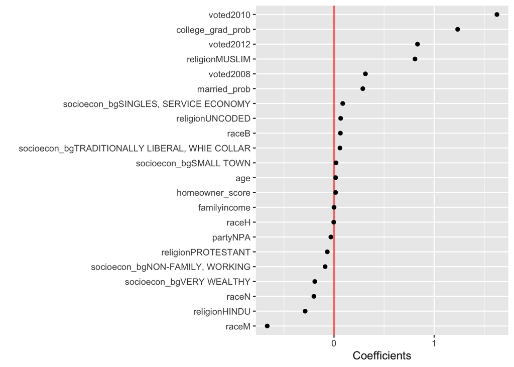

### Briefly interpret the estimated coefficients. What kind of pattern do you observe in the estimate?